# Modeling and prediction for movies

## Setup

### Load packages

```r
library(ggplot2)
library(dplyr)
library(statsr)
library(GGally)
```

### Load data

```r
load("movies.Rdata")
```

## Part 1: Data

“The data set is comprised of 651 randomly sampled movies produced and released before 2016.” Since random sampling was used, any conclusion form the data can be gerneralized to all movies producted and released before 2016.  
Since we can not find random assignment was used, we can only get the association between variables.

## Part 2: Research question

What’s the relationship between a movies’ rating on IMDB and it’s audience score on Rotten Tomatoes.What’s more, can we use the audience score on Rotten Tomatoes to estimate it’s rating on IMDB?  
Do the two websites share common valus to adjust a movies? I think a good movie shoule be marked as good across different groups of peoples.

## Part 3: Exploratory data analysis

let’s plot the relationship between audience score on Rotten Tomatoes and Rating on IMDB.  
here are the variables:

**imdb_rating:** rating on IMDB

**audience_score:** score on Rotten Tomatoes.

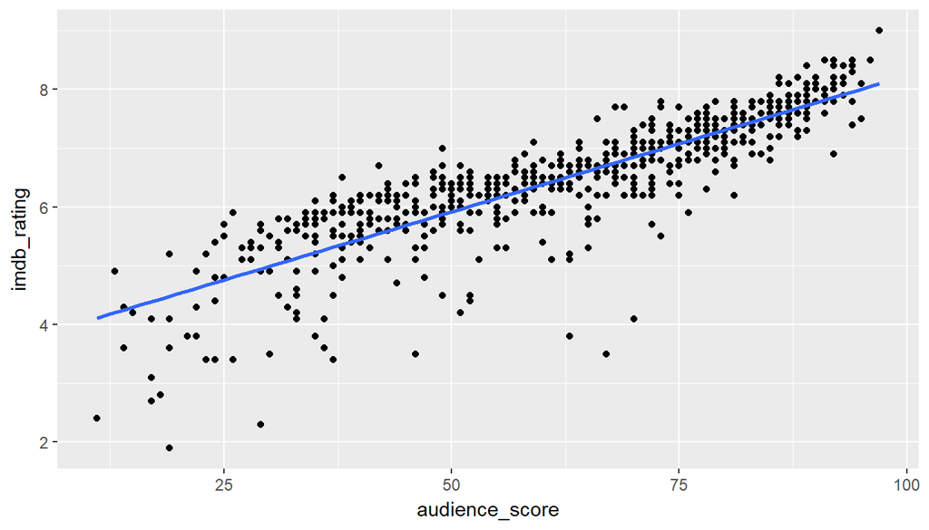

```r
ggplot(movies, aes(x = audience_score, y = imdb_rating)) + geom_point() + stat_smooth(method = "lm", se = FALSE)
```

We can see a strong, positive, lieanr relationship.  
Next, let’s compute the correlation and the R2.

```r
movies %>% summarise(correlation = cor(imdb_rating, audience_score), R2 = cor(imdb_rating, audience_score)^2)
```

```
## # A tibble: 1 x 2
##   correlation        R2
##         <dbl>     <dbl>
## 1   0.8648652 0.7479917
```

The correlation and the R2 is prety heigh. It means about 74.8% of the variability in the imdb_rating is explained by the audience.

When fitting a least squares line, we generally require **linearity, nearly normall residuals, constant variability** and **independent obervations.**

let’s cheek it now.  
Base on the scatter plot about imdb_rating and audience_socre, we can find there is a linear trend.

Now let’s check the “nearly normal residuals” assumption.

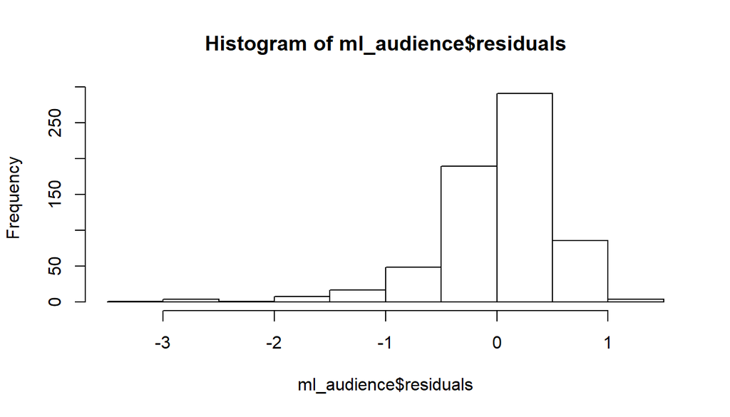

```r
ml_audience = lm(imdb_rating ~ audience_score, data = movies)
hist(ml_audience$residuals)
```

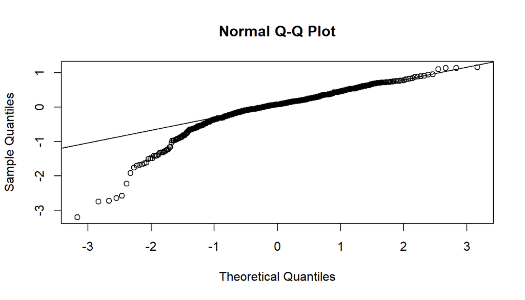

```r
qqnorm(ml_audience$residuals)
qqline(ml_audience$residuals)
```

The residuals appears to be a little left skewed, but still normal.

Now let’s check the “constant variability” assumoption.

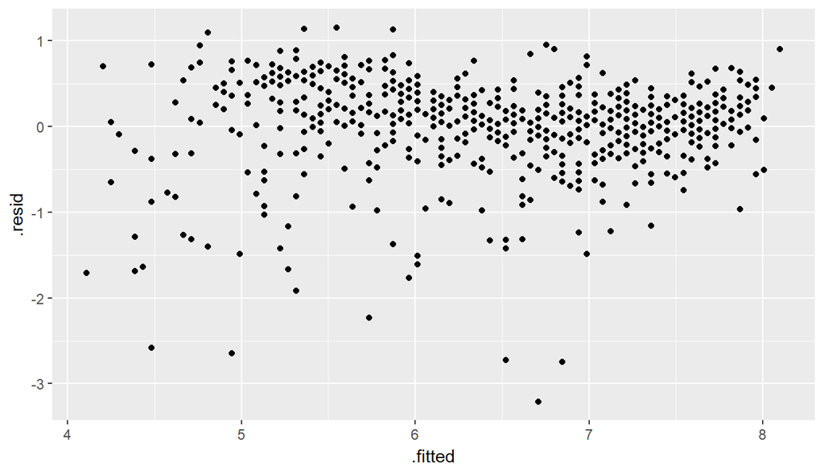

```r
ggplot(ml_audience, aes(x = .fitted, y = .resid)) + geom_point()
```

The variance is approximately constant.

Now let’s check the “independent observations” assumption.

let’s plot the residuals versus it’s index. (Plotting residuals in the order that their corresponding observations were collected helps identify connections between successive observations.)

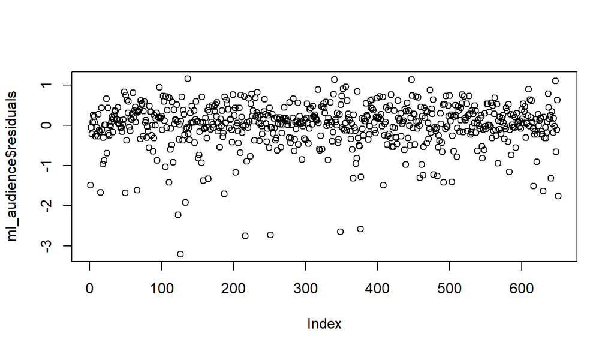

```r
plot(ml_audience$residuals)
```

The data is randomly sampled movies. And base on the residuals plot, It’s obvious that the data is not time series data.

**conclusion:** there is a strong, positive, linear relationship between imdb_rating and audience_score. And we can use audience_score to predict the imdb_rating.

## Part 4: Modeling

**Full model variables：** runtime, thrt_rel_year, thtr_rel_month, imdb_num_votes, audience_score, best_dir_win, top_200_box.

**Excluded variables:**  
I think the critics_score(critics score on Rotten Tomatoes) can be a helpful variable for this model. But the critics_score may correlate with other variables.  
let’s check it.

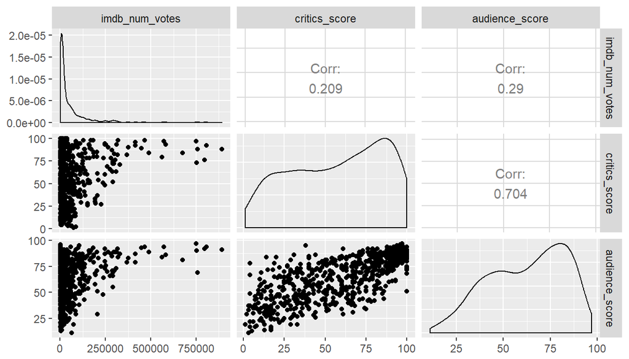

```r
ggpairs(movies, columns = c(14, 16, 18))
```

The critics_score and audience_score are collinear. Since collinearity complicates model estimation, we exclude the critics_score variables. * * *

**model selection method:** backward elimination with the p-value approach.  
**reson:**I care about understanding which variables are statistically significant predictors of the imdb_rating variable, so the p-value approach is suitable.  
let’s begain with the full model.

```r
ml_multi = lm(imdb_rating ~ runtime + thtr_rel_year + thtr_rel_month  +  imdb_num_votes + audience_score + best_dir_win + top200_box, data = movies)
summary(ml_multi)
```

```
##
## Call:
## lm(formula = imdb_rating ~ runtime + thtr_rel_year + thtr_rel_month +
##     imdb_num_votes + audience_score + best_dir_win + top200_box,
##     data = movies)
##
## Residuals:
##      Min       1Q   Median       3Q      Max
## -3.11503 -0.18979  0.07165  0.30058  1.08711
##
## Coefficients:
##                   Estimate Std. Error t value Pr(>|t|)
## (Intercept)     -3.120e-01  3.976e+00  -0.078   0.9375
## runtime          5.187e-03  1.199e-03   4.326 1.76e-05 ***
## thtr_rel_year    1.703e-03  1.979e-03   0.861   0.3896
## thtr_rel_month   5.311e-03  6.003e-03   0.885   0.3766
## imdb_num_votes   5.157e-07  2.191e-07   2.354   0.0189 *
## audience_score   4.461e-02  1.081e-03  41.257  < 2e-16 ***
## best_dir_winyes  1.065e-01  8.737e-02   1.219   0.2233
## top200_boxyes   -1.041e-01  1.458e-01  -0.714   0.4756
## ---
## Signif. codes:  0 '***' 0.001 '**' 0.01 '*' 0.05 '.' 0.1 ' ' 1
##
## Residual standard error: 0.5288 on 642 degrees of freedom
##   (1 observation deleted due to missingness)
## Multiple R-squared:  0.7649, Adjusted R-squared:  0.7624
## F-statistic: 298.5 on 7 and 642 DF,  p-value: < 2.2e-16
```

Drop the top200_box.

```r
ml_multi = lm(imdb_rating ~ runtime + thtr_rel_year + thtr_rel_month + imdb_num_votes + audience_score + best_dir_win , data = movies)
summary(ml_multi)
```

```
##
## Call:
## lm(formula = imdb_rating ~ runtime + thtr_rel_year + thtr_rel_month +
##     imdb_num_votes + audience_score + best_dir_win, data = movies)
##
## Residuals:
##     Min      1Q  Median      3Q     Max
## -3.1156 -0.1875  0.0756  0.3008  1.0859
##
## Coefficients:
##                   Estimate Std. Error t value Pr(>|t|)
## (Intercept)     -6.511e-01  3.946e+00  -0.165   0.8690
## runtime          5.176e-03  1.199e-03   4.319 1.82e-05 ***
## thtr_rel_year    1.874e-03  1.963e-03   0.955   0.3401
## thtr_rel_month   5.089e-03  5.992e-03   0.849   0.3961
## imdb_num_votes   4.728e-07  2.106e-07   2.245   0.0251 *
## audience_score   4.461e-02  1.081e-03  41.275  < 2e-16 ***
## best_dir_winyes  1.088e-01  8.728e-02   1.247   0.2129
## ---
## Signif. codes:  0 '***' 0.001 '**' 0.01 '*' 0.05 '.' 0.1 ' ' 1
##
## Residual standard error: 0.5286 on 643 degrees of freedom
##   (1 observation deleted due to missingness)
## Multiple R-squared:  0.7648, Adjusted R-squared:  0.7626
## F-statistic: 348.4 on 6 and 643 DF,  p-value: < 2.2e-16
```

Drop the thtr_rel_month

```r
ml_multi = lm(imdb_rating ~ runtime + thtr_rel_year  + imdb_num_votes + audience_score + best_dir_win , data = movies)
summary(ml_multi)
```

```
##
## Call:
## lm(formula = imdb_rating ~ runtime + thtr_rel_year + imdb_num_votes +
##     audience_score + best_dir_win, data = movies)
##
## Residuals:
##     Min      1Q  Median      3Q     Max
## -3.1009 -0.1821  0.0790  0.2971  1.0885
##
## Coefficients:
##                   Estimate Std. Error t value Pr(>|t|)
## (Intercept)     -6.922e-01  3.945e+00  -0.175   0.8608
## runtime          5.370e-03  1.176e-03   4.564    6e-06 ***
## thtr_rel_year    1.902e-03  1.963e-03   0.969   0.3329
## imdb_num_votes   4.780e-07  2.104e-07   2.271   0.0235 *
## audience_score   4.460e-02  1.080e-03  41.276   <2e-16 ***
## best_dir_winyes  1.107e-01  8.723e-02   1.270   0.2047
## ---
## Signif. codes:  0 '***' 0.001 '**' 0.01 '*' 0.05 '.' 0.1 ' ' 1
##
## Residual standard error: 0.5285 on 644 degrees of freedom
##   (1 observation deleted due to missingness)
## Multiple R-squared:  0.7645, Adjusted R-squared:  0.7627
## F-statistic: 418.1 on 5 and 644 DF,  p-value: < 2.2e-16
```

Drop the thtr_rel_year

```r
ml_multi = lm(imdb_rating ~ runtime  + imdb_num_votes + audience_score + best_dir_win , data = movies)
summary(ml_multi)
```

```
##
## Call:
## lm(formula = imdb_rating ~ runtime + imdb_num_votes + audience_score +
##     best_dir_win, data = movies)
##
## Residuals:
##      Min       1Q   Median       3Q      Max
## -3.08754 -0.18540  0.08396  0.31149  1.10456
##
## Coefficients:
##                  Estimate Std. Error t value Pr(>|t|)
## (Intercept)     3.129e+00  1.319e-01  23.717  < 2e-16 ***
## runtime         5.209e-03  1.165e-03   4.473 9.12e-06 ***
## imdb_num_votes  5.256e-07  2.046e-07   2.569   0.0104 *
## audience_score  4.450e-02  1.076e-03  41.360  < 2e-16 ***
## best_dir_winyes 1.015e-01  8.670e-02   1.171   0.2422
## ---
## Signif. codes:  0 '***' 0.001 '**' 0.01 '*' 0.05 '.' 0.1 ' ' 1
##
## Residual standard error: 0.5285 on 645 degrees of freedom
##   (1 observation deleted due to missingness)
## Multiple R-squared:  0.7642, Adjusted R-squared:  0.7627
## F-statistic: 522.5 on 4 and 645 DF,  p-value: < 2.2e-16
```

Drop the best_dir_win

```r
ml_multi = lm(imdb_rating ~ runtime   + imdb_num_votes + audience_score , data = movies)
summary(ml_multi)
```

```
##
## Call:
## lm(formula = imdb_rating ~ runtime + imdb_num_votes + audience_score,
##     data = movies)
##
## Residuals:
##     Min      1Q  Median      3Q     Max
## -3.0892 -0.1874  0.0837  0.3133  1.1026
##
## Coefficients:
##                 Estimate Std. Error t value Pr(>|t|)
## (Intercept)    3.104e+00  1.302e-01  23.833  < 2e-16 ***
## runtime        5.476e-03  1.143e-03   4.793 2.04e-06 ***
## imdb_num_votes 5.508e-07  2.035e-07   2.706  0.00698 **
## audience_score 4.453e-02  1.076e-03  41.389  < 2e-16 ***
## ---
## Signif. codes:  0 '***' 0.001 '**' 0.01 '*' 0.05 '.' 0.1 ' ' 1
##
## Residual standard error: 0.5286 on 646 degrees of freedom
##   (1 observation deleted due to missingness)
## Multiple R-squared:  0.7637, Adjusted R-squared:  0.7626
## F-statistic: 695.8 on 3 and 646 DF,  p-value: < 2.2e-16
```

**model diagnostics:** Multiple regression method generally depend on the following four assumptions:

1,the residuals of the moudel are nearly normal.

2,the variability of the residuals is nearly constant.

3,the residuals are independent.

4,each variable is linear to the outcome.

First, let’s check the whether the residuals of the moudel are nearly normal.

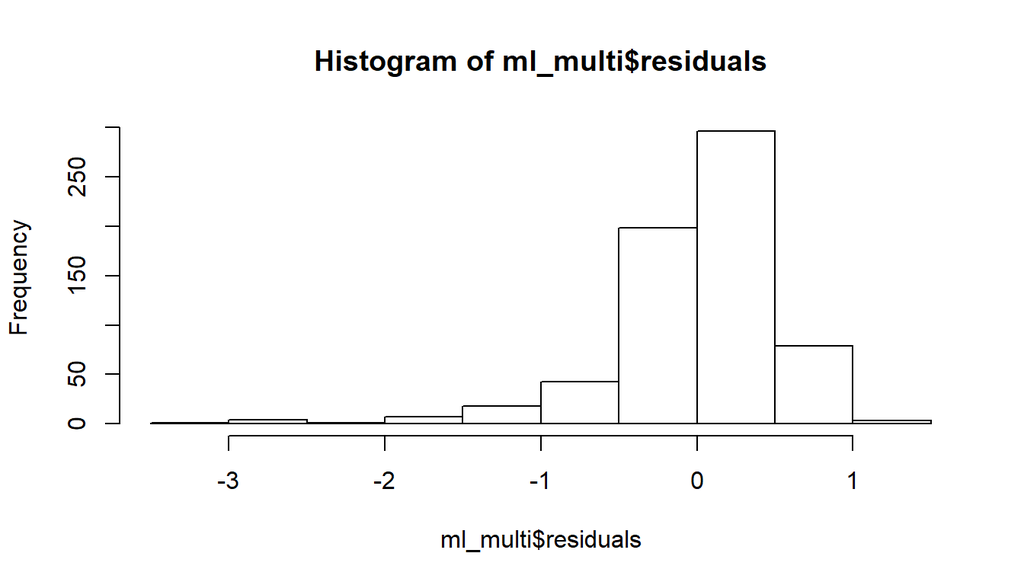

```r
hist(ml_multi$residuals)
```

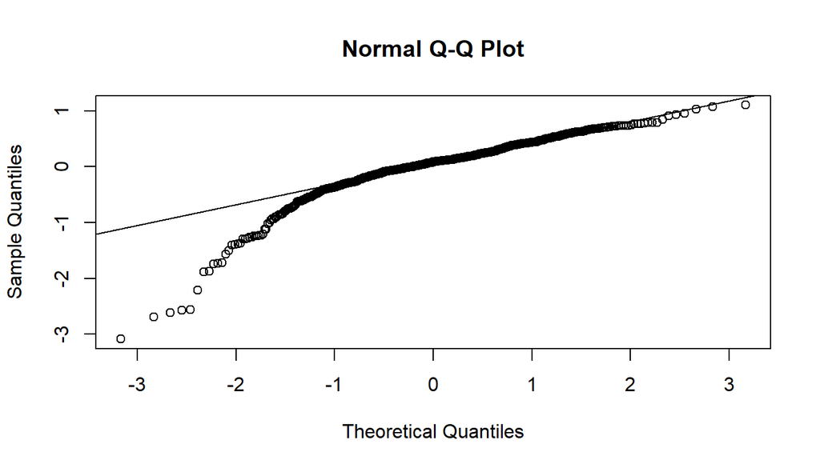

```r
qqnorm(ml_multi$residuals)
qqline(ml_multi$residuals)
```

The residuals also appears to be a littel left skewed, but still normal.

Second, check the “constant variablility of residuals” assuption.

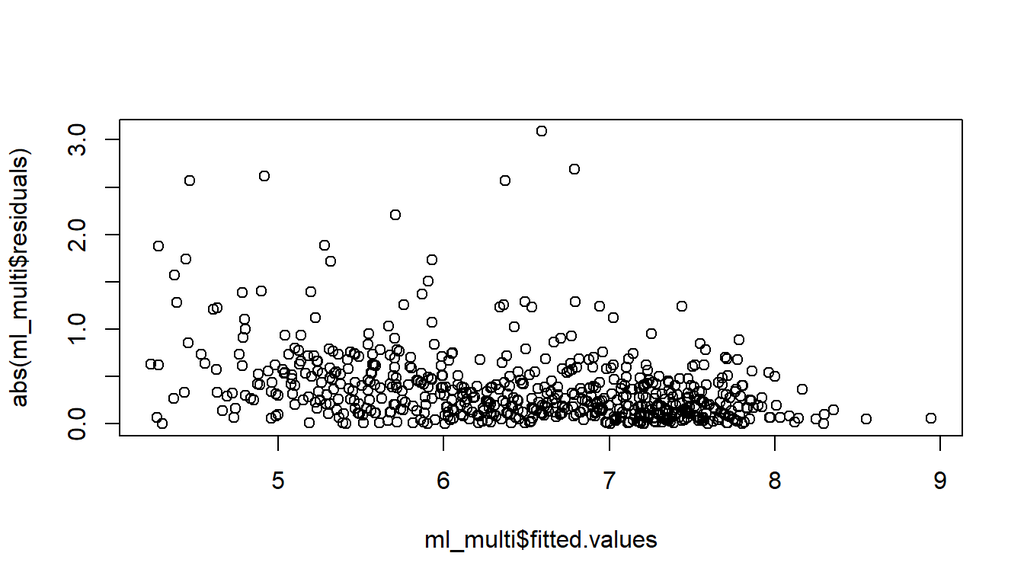

```r
plot(abs(ml_multi$residuals) ~ ml_multi$fitted.values)
```

The residuals’ variance is approximately constant.

Next, check whether the residuals are independent.

Let’s plot the residuals versus it’s index.

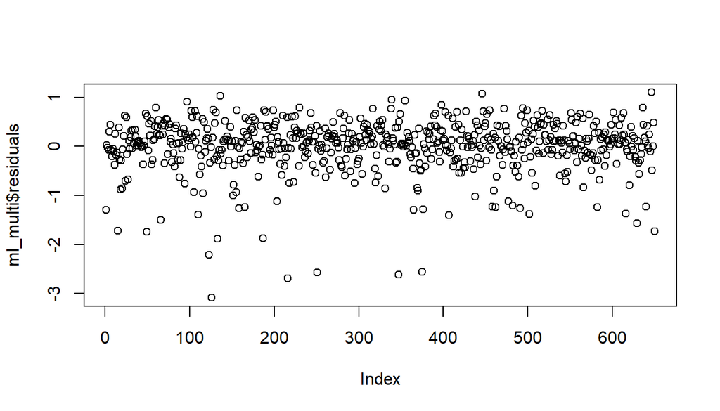

```r
plot(ml_multi$residuals)
```

Since the data is comprised of randomly sampled movies. And base on the residuals plot, the data is obvious not time series data. This assuption appears to met.

last,let’s check the “each variable is linearly to the outcome” assuption.

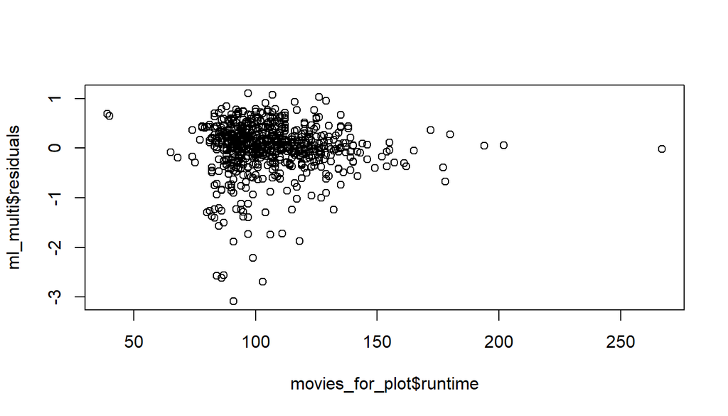

```r
movies_for_plot <- movies %>% filter(!is.na(runtime),!is.na(imdb_num_votes),!is.na(audience_score))
plot(ml_multi$residuals ~ movies_for_plot$runtime)
```

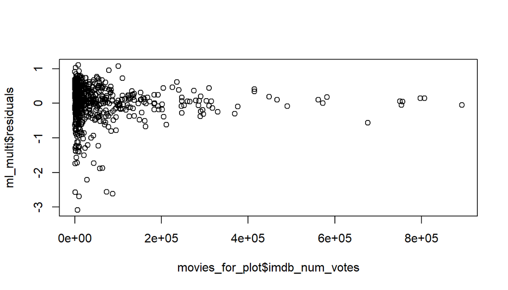

```r
plot(ml_multi$residuals ~ movies_for_plot$imdb_num_votes)
```

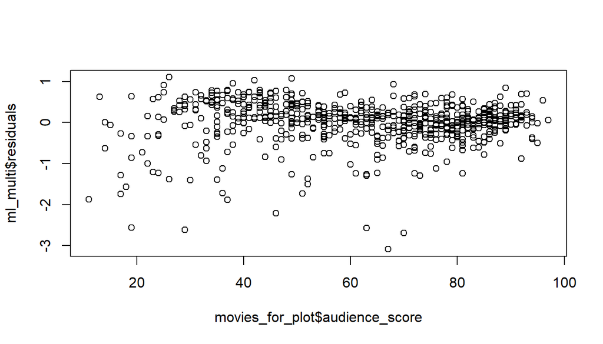

```r
plot(ml_multi$residuals ~ movies_for_plot$audience_score)
```

The residuals versus imdb_num_votes appears to be a fan shaped pattern. The other residuals plots appears to be no pattern. SO this assumption is a little violated, but it do not go too far.

## Part 5: Prediction

Let’s predict the “la la land”.  
Here are some infomation:  
**runtime:** 2h8mins  
**imdb_rating:** 8.2  
**imdb_num_votes:** 296641  
**audience_score:**82  
Now let’s predict this movie.

```r
la_la_land <- data.frame(runtime = 2*60 + 8, imdb_num_votes = 296641, audience_score = 82)
predict(ml_multi, la_la_land, interval = "prediction", level = 0.95)
```

```
##        fit     lwr      upr
## 1 7.619812 6.57711 8.662514
```

The prediction interval with 95% confidence interval is (6.57711, 8.662514).  
**Interpretation:**we are 95% confidence that the rating on IMDB of “la la land” is between 6.57711 and 8.662514.  
reference:  
http://www.imdb.com/title/tt3783958/?ref_=nv_sr_1  
https://www.rottentomatoes.com/m/la_la_land

## Part 6: Conclusion

I should add more variables to the full mode, so that we can get a heigher adjusted R2.